# HAR

Enzo Alda

Sunday, January 25, 2015

## Motivation

This document describes the analysis of data collected as part of a human activity recognition (HAR) experiment. The data was obtained from accelerometers on the belt, forearm, arm, and dumbell of 6 participants, while performing a series of exercises. They were asked to perform barbell lifts correctly andincorrectly in 5 different ways. More information is available in the Weight Lifting Exercise Dataset section from the website here: http://groupware.les.inf.puc-rio.br/har.

The aim of the analysis here presented is to develop a predictive algorithm to determine how well a subject is performing a given exercise given the data from the sensors: i.e. which one of the 5 categories best corresponds to a given observation.

## Data loading and pre-processing

We eliminated variables that only have values on the ‘new window’ observation on the basis that such records (406 in total) were very few compared to the size of the dataset. We considered imputing those values, as they appear to be related to the entire window, to the other observations in the same window. However decided against doing so for several reasons: 1) some values were missing (or divide by zero errors) on those observations as well, and 2) a quick preliminary analysis of the distribution of a handful of variates of those 406 records across the different classification categories (‘classe’) revealed nothing of particular interesting. Therefore we concluded that efforts to add information from those 406 records were not worth the trouble. Those variables have names matching patterns: “kurtosis”, “skewness”, “max”, “min”, “amplitude”, “var”, “avg”, and “stddev”. We also eliminated timestamps, window numbers, the new window indicator, and the sequential number ‘X’ on the basis that those variables cannot be meaningful when predicting new, out-of-sample, observations: e.g. what is “your” ‘X’ or your window number if you want to apply a model to yourself to predict how well you are exercising, later on.

A controversial decision: we did leave ‘user_name’ as a predictor. To the extent that different subjects in our training set may exhibit (we did not test for this) different measurement patterns relative to the ‘classe’ categories, we wanted to capture that information. The reason is simple: the 20 test cases (graded) did contain the same subjects. That is a “bad” reason for keeping such variable. If we want our model to generalize well to other people, which is a reasonable, and presumably the noble goal, for a study like this, we should leave it out, or replace it with subject related biomeasures that can be taken on new subjects, like weight, height, etc. So, we are guilty as charged: normally we would exlclude such variable, but we didn’t. We could easily rebuild our models without the subjects and see if we gained any value from our “cheating”. For the sake of brevity we didn’t.

Last, but very important, the so-called “testing” set of 20 observations is really a “challenge” test set for grading purposes. It has very few observations, for obvious reasons. We need to set aside a test set of reasonable size, and refrain from using when building our models, in order to peroperly assess our out-of-sample error.

```r
# Libraries used
library(caret);
```

```r
library(ggplot2);
library(randomForest);
# Note that 'pml-training' is actually our entire data set
data <- read.csv("pml-training.csv");

# Discard columns
column.names <- names(data);
discard.pattern <- c(
    "X", "timestamp", "window",
    "kurtosis_", "skewness_",
    "max_", "min_", "amplitude_",
    "var_", "avg_", "stddev_"
);
discarded <- NULL;
for (pattern in discard.pattern) {
    discarded <- c(discarded, grep(pattern, column.names))
}
discarded <- column.names[discarded];
for (column in discarded) {
    data[column] <- NULL;
}

# Done discarding. Split data into training and test sets.
# Set seed for partition reproducibility
set.seed(32343);
# Partition data
sub <- createDataPartition(y = data$classe, p = 0.80, list = FALSE);
training <- data[sub,];
testing <- data[-sub,];
```

## Model selection and testing

We first tried a pure linear model. Note that the factor levels (A,B,C,D,E) of the ‘classe’ variable form a ranking. So we convert ‘classe’, for the purpose of building the model, into a numerical variable (with values 1,2,3,4,5) corresponding to the ordering of the original factor levels.

```r
#
# Model 1
#
model1 <- function(training, testing) {
    # Set seed for reproducibility
    set.seed(997);

    # Clone training set (for dependent variable transformation)
    training.lm <- training;
    training.lm$nclasse <- as.numeric(training.lm$classe);
    training.lm$classe <- NULL;

    # Train model
    model <- train(nclasse ~ ., data = training.lm, method = "lm");

    # Compute predictions
    predictions <- predict(model, newdata = testing);
    predictions[predictions < 1] <- 1;
    predictions[5 < predictions] <- 5;
    predictions <- round(predictions);

    # Clone testing set (for dependent variable transformation)
    testing.lm <- testing;
    testing.lm$nclasse <- as.numeric(testing.lm$classe);

    # Compute confusion matrix
    confusion.matrix <- confusionMatrix(testing.lm$nclasse, predictions);

    # Free memory
    training.lm <- NULL;
    testing.lm <- NULL;

    # Return model and prediction results
    list(model=model, result=confusion.matrix);
}

m1 <- model1(training, testing);
```

Here are the results for model 1.

```r
m1$model
```

```
## Linear Regression
##
## 15699 samples
##    53 predictor
##
## No pre-processing
## Resampling: Bootstrapped (25 reps)
##
## Summary of sample sizes: 15699, 15699, 15699, 15699, 15699, 15699, ...
##
## Resampling results
##
##   RMSE       Rsquared   RMSE SD      Rsquared SD
##   0.9677094  0.5708564  0.009454104  0.007339001
##
##
```

```r
m1$result
```

```
## Confusion Matrix and Statistics
##
##           Reference
## Prediction   1   2   3   4   5
##          1 478 505 128   4   1
##          2  48 279 364  65   3
##          3   1 132 476  75   0
##          4   0  91 319 222  11
##          5   1  13 184 290 233
##
## Overall Statistics
##
##                Accuracy : 0.4303
##                  95% CI : (0.4147, 0.446)
##     No Information Rate : 0.375
##     P-Value [Acc > NIR] : 7.199e-13
##
##                   Kappa : 0.294
##  Mcnemar's Test P-Value : < 2.2e-16
##
## Statistics by Class:
##
##                      Class: 1 Class: 2 Class: 3 Class: 4 Class: 5
## Sensitivity            0.9053  0.27353   0.3236  0.33841  0.93952
## Specificity            0.8121  0.83465   0.9152  0.87114  0.86721
## Pos Pred Value         0.4283  0.36759   0.6959  0.34526  0.32316
## Neg Pred Value         0.9822  0.76580   0.6928  0.86768  0.99532
## Prevalence             0.1346  0.26001   0.3750  0.16722  0.06322
## Detection Rate         0.1218  0.07112   0.1213  0.05659  0.05939
## Detection Prevalence   0.2845  0.19347   0.1744  0.16391  0.18379
## Balanced Accuracy      0.8587  0.55409   0.6194  0.60478  0.90336
```

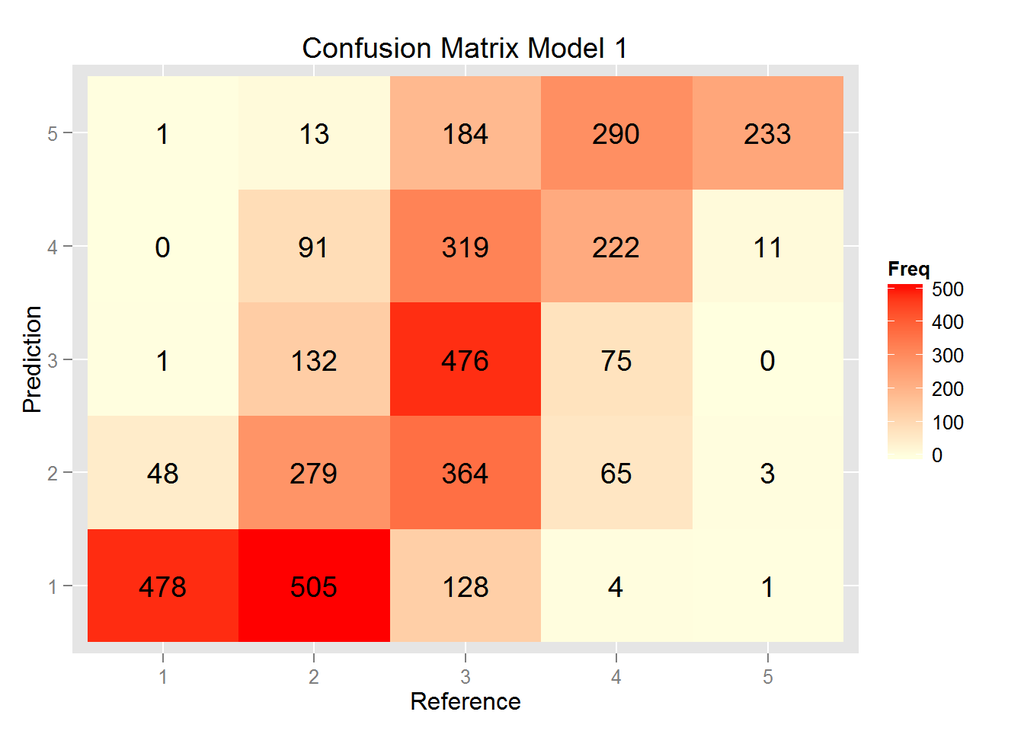

```r
confusion.table.1 <- as.data.frame(m1$result$table);

plot.1 <-
    ggplot(confusion.table.1, aes(Reference, Prediction, group=Prediction)) +
    ggtitle("Confusion Matrix Model 1") +
    geom_tile(aes(fill = Freq)) +
    geom_text(aes(fill = Freq, label = Freq)) +
    scale_fill_gradient(low = "light yellow", high = "red");

plot.1
```

It is obvious that there is predictive power in this model, as evidenced by the aggregation of values along the diagonal. The statistical significance is high, but the accuracy of the model, a mere 43%, is very weak.

We tried several models with different pre-processing and training methods, as well as choice of predictors. Some of our models used PCA. Others condensed measures taken over axes into a single, corresponding, ‘amplitude’ measure, using formulae of the form: sqrt(measure.x^2, measure.y^2, measure.z^2). For brevity we only present here how we obtained the model used to predict the 20 test cases given as a challenge. The model produced a perfect prediction of the test set.

Model 8 is a brute force (using all potential predictors) GBM model, with parameters estimated via cross-validation (10 K-folds).

```r
#
# Model 8
#
model8 <- function(training, testing) {
    # Define training control parameters
    control <- trainControl(method="cv", number=10, repeats=1, allowParallel=T);

    # Train model
    model <- train(classe ~ ., data=training, method="gbm", trControl=control, verbose=F);

    # Compute predictions
    predictions <- predict(model, newdata=testing);
    # Compute confusion matrix
    confusion.matrix <- confusionMatrix(testing$classe, predictions);

    # Return model and prediction results
    list(model=model, result=confusion.matrix);
}

m8 <- model8(training, testing);
```

Here are the results for model 8:

```r
m8$model
```

```
## Stochastic Gradient Boosting
##
## 15699 samples
##    53 predictor
##     5 classes: 'A', 'B', 'C', 'D', 'E'
##
## No pre-processing
## Resampling: Cross-Validated (10 fold)
##
## Summary of sample sizes: 14127, 14129, 14128, 14130, 14130, 14129, ...
##
## Resampling results across tuning parameters:
##
##   interaction.depth  n.trees  Accuracy   Kappa      Accuracy SD
##   1                   50      0.7532978  0.6873548  0.006825487
##   1                  100      0.8198615  0.7719729  0.007344589
##   1                  150      0.8545756  0.8159496  0.006079960
##   2                   50      0.8555333  0.8168686  0.008217978
##   2                  100      0.9084014  0.8840774  0.005525274
##   2                  150      0.9354092  0.9182686  0.005185817
##   3                   50      0.8975093  0.8702423  0.005232331
##   3                  100      0.9445812  0.9298660  0.004764075
##   3                  150      0.9625438  0.9526131  0.004417027
##   Kappa SD
##   0.008699542
##   0.009273883
##   0.007730969
##   0.010479546
##   0.007007080
##   0.006557973
##   0.006655230
##   0.006026921
##   0.005585077
##
## Tuning parameter 'shrinkage' was held constant at a value of 0.1
## Accuracy was used to select the optimal model using  the largest value.
## The final values used for the model were n.trees = 150,
##  interaction.depth = 3 and shrinkage = 0.1.
```

```r
m8$result
```

```
## Confusion Matrix and Statistics
##
##           Reference
## Prediction    A    B    C    D    E
##          A 1092   17    6    0    1
##          B   29  711   18    1    0
##          C    0   26  646   12    0
##          D    0    3   31  600    9
##          E    1    8    5   10  697
##
## Overall Statistics
##
##                Accuracy : 0.9549
##                  95% CI : (0.9479, 0.9612)
##     No Information Rate : 0.286
##     P-Value [Acc > NIR] : < 2.2e-16
##
##                   Kappa : 0.9429
##  Mcnemar's Test P-Value : NA
##
## Statistics by Class:
##
##                      Class: A Class: B Class: C Class: D Class: E
## Sensitivity            0.9733   0.9294   0.9150   0.9631   0.9859
## Specificity            0.9914   0.9848   0.9882   0.9870   0.9925
## Pos Pred Value         0.9785   0.9368   0.9444   0.9331   0.9667
## Neg Pred Value         0.9893   0.9829   0.9815   0.9930   0.9969
## Prevalence             0.2860   0.1950   0.1800   0.1588   0.1802
## Detection Rate         0.2784   0.1812   0.1647   0.1529   0.1777
## Detection Prevalence   0.2845   0.1935   0.1744   0.1639   0.1838
## Balanced Accuracy      0.9823   0.9571   0.9516   0.9750   0.9892
```

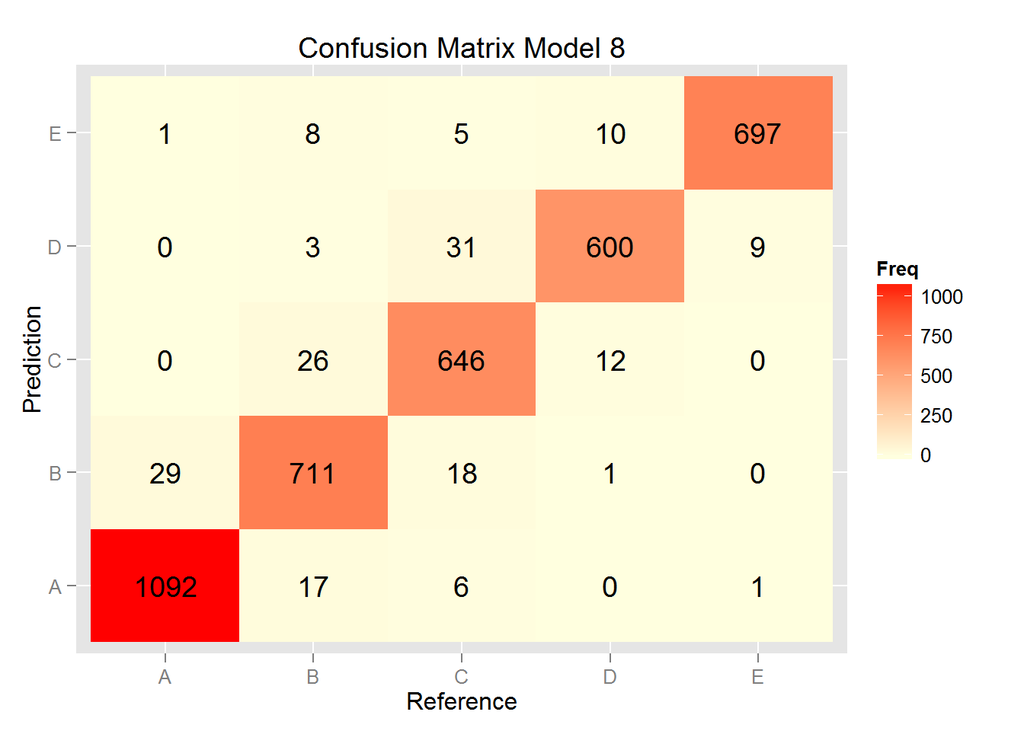

```r
confusion.table.8 <- as.data.frame(m8$result$table);

plot.8 <-
    ggplot(confusion.table.8, aes(Reference, Prediction, group=Prediction)) +
    ggtitle("Confusion Matrix Model 8") +
    geom_tile(aes(fill = Freq)) +
    geom_text(aes(fill = Freq, label = Freq)) +
    scale_fill_gradient(low = "light yellow", high = "red");

plot.8
```

We can appreciate that this model has excellent predictive power. The out-of-sample error (mis-classification rate) is expected to be less than 5% based on the classification rate accuracy of over 95% obtained by comparing model predictions against the actual values on the testing set. Note that the testing set, which we set aside early on, was never taken into consideration while training our models, and is therefore an honest set for estimating out-of-sample error. Here we show how to compute the error manually:

```r
table <- m8$result$table;
total <- sum(table);
ok <- sum(diag(5) * table);

error <- 1 - ok/total;
error
```

```
## [1] 0.04511853
```

### References

Velloso, E.; Bulling, A.; Gellersen, H.; Ugulino, W.; Fuks, H. Qualitative Activity Recognition of Weight Lifting Exercises. Proceedings of 4th International Conference in Cooperation with SIGCHI (Augmented Human ’13) . Stuttgart, Germany: ACM SIGCHI, 2013.